# Package miscset introduction

Sven E. Templer

2016-10-30

# About

R package **miscset** version `1.0.4`.

A collection of miscellaneous methods to simplify various tasks, including plotting, data.frame and matrix transformations, environment functions, regular expression methods, and string and logical operations, as well as numerical and statistical tools.

Most of the methods are simple but useful wrappers of common base `R` functions, which extend S3 generics or provide default values for important parameters.

# Index

- Installation and Introduction
- Plots
  - ciplot - Barplot with Confindence Intervals
  - ggplotGrid - Arrange a List of ggplots
  - gghl - HTML Colours Like ggplot2
  - plotn - Plot Nothing (but a Plot)
- Data Frame and Matrix
  - sort - Sort data.frame Objects
  - do.rbind - Bind data.frames in a List by Rows
  - enpaire - Create a Pairwise List from a Matrix
  - squarematrix - Create a Square Matrix
  - textable - Table to Latex
- Environment
  - help.index - Open The Package Help Index Page
  - lload - Load RData Objects to a List
  - lsall - List Object Details
  - rmall - Remove All Objects from Global Environment
- Regular Expression
  - mgrepl - Multiple Pattern Matching and Replacement
  - gregexprind - Pattern Matching and Extraction
- String and Logical
  - collapse - Collapse objects
  - leading0 - Numeric to Character with Leading Zero(s)
  - strextr - Extract a Substring
  - strpart - Split String and Return Part
  - strrev - Reverse Text Strings
  - duplicates and duplicatei - Determine Duplicates
- Numerical and Statistical
  - p2star - P Value Significance Level Indicator
  - confint.numeric - Confidence Intervals for Numeric Vectors
  - ntri - Return Triangular Numbers
  - scale0 and scaler - Scale Numeric Values to Defined Ranges
  - nunique and uniquei - Amount and Index of Unique Values

# Installation and Introduction

Install the package from `cran` or from `github` by using the following commands:

```r
# from CRAN
install.packages("miscset")

# from github - latest release version
install.packages("devtools")
devtools::install_github("setempler/miscset", build_vignettes = TRUE)

# from github - development version
install.packages("devtools")
devtools::install_github("setempler/miscset@develop", build_vignettes = TRUE)
```

Development of the package is traceable at [github](https://github.com/setempler/miscset). In case you find any bugs or have other issues concerning the package development, feel free to make use of the github issues.

A more detailed help for each function can be viewed on the `R` help pages. For a general index, after installation and loading of the package, display it with:

```r
help.index(miscset)
```

This works as well for other packages. To view the single help pages, call the function’s name with a `?` prepended, e.g.:

```r
?help.index
```

The following chapters will describe the functions from the `miscset` package. The prerequisites to run all vignette examples are to load the following packages, and generate the sample data:

```r
library(miscset)
library(ggplot2)
d <- data.frame(a=c(2,1,3,NA,1), b=2:6, c=5:1)
m <- matrix(letters[1:9], 3, 3, dimnames = list(1:3,1:3))
```

# Plot methods

(back to top)

### Function `ciplot`

Plot a bargraph with error bars. Input data is a list with numeric vectors. Functions to calculate bar heights (e.g. `mean` by default) and error bar sizes (e.g. `confint.numeric` by default) can be modified (e.g. `sd` for error bars).

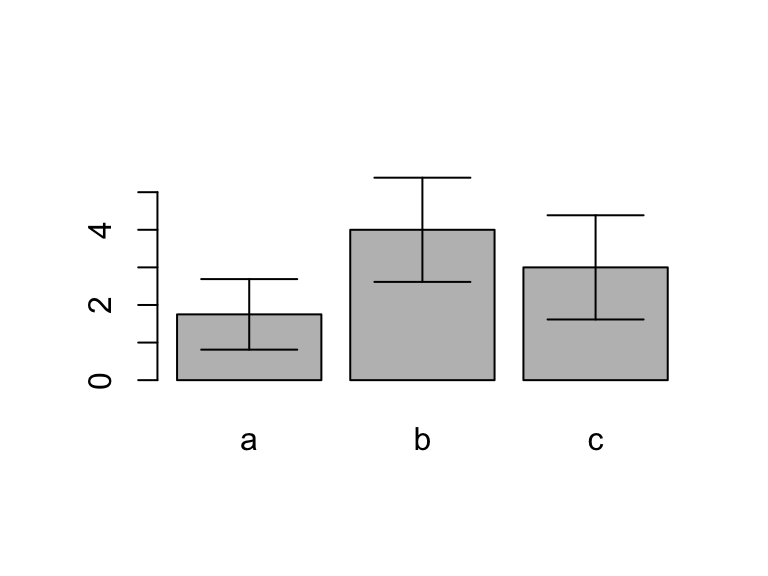

```r
ciplot(d)
```

### Function `ggplotGrid`

Arrange ggplots on a grid (plot window or pdf file). Supply a list with `ggplot` objects and define number of rows and/or columns. If a `path` is supplied, the plot is written to that file instead of the internal graphics device.

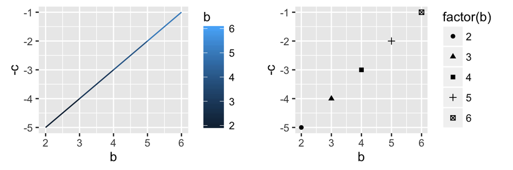

```r
plots <- list(
  ggplot(d, aes(x = b, y= -c, col = b)) + geom_line(),
  ggplot(d, aes(x = b, y = -c, shape = factor(b))) + geom_point())
ggplotGrid(plots, ncol = 2)
```

The function `ggplotGridA4` supports direct output to DIN A4 sized pdfs.

### Function `gghcl`

Generate a character vector with html values from a color hue as in `ggplot`.

```r
n <- length(d)
gghcl(n)
```

```
[1] "#F8766D" "#00BA38" "#619CFF"
```

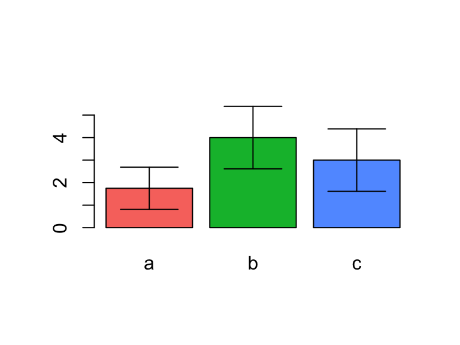

```r
ciplot(d, col = gghcl(n))
```

### Function `plotn`

Create an empty plot. Useful to fill `layout`.

```r
plotn()
```

# Data Frame and Matrix Methods

(back to top)

### Function `sort`

Sort `data.frame` objects. This extends the functionality of the base R distributed generic `sort`. Define multiple columns by column names as character vector or expression.

```r
d
```

```
   a b c
1  2 2 5
2  1 3 4
3  3 4 3
4 NA 5 2
5  1 6 1
```

```r
sort(d, by = c("a", "c"))
```

```
  a b c
5 1 6 1
2 1 3 4
1 2 2 5
3 3 4 3
```

### Function `do.rbind`

A wrapper function to row-bind `data.frame` objects in a list with `do.call` and `rbind`. Object names from the list are inserted as additional column.

```r
d[1:3,]
```

```
  a b c
1 2 2 5
2 1 3 4
3 3 4 3
```

```r
do.rbind(list(first=d[1:2,], second=d[1:3,]))
```

```
    Name a b c
1  first 2 2 5
2  first 1 3 4
3 second 2 2 5
4 second 1 3 4
5 second 3 4 3
```

### Function `enpaire`

Generate a pairwise list (`data.frame`) of a matrix containing row and column id and upper and lower triangle values.

```r
m
```

```
  1   2   3
1 "a" "d" "g"
2 "b" "e" "h"
3 "c" "f" "i"
```

```r
enpaire(m)
```

```
  row col lower upper
1   1   2     b     d
2   1   3     c     g
3   2   3     f     h
```

### Function `squarematrix`

Generate a symmetric (square) matrix from an unsymmetric one using column and row names. Fills empty cells with `NA`.

```r
m[-1,]
```

```
  1   2   3
2 "b" "e" "h"
3 "c" "f" "i"
```

```r
squarematrix(m[-1,])
```

```
  1   2   3
1 NA  NA  NA
2 "b" "e" "h"
3 "c" "f" "i"
```

### Function `textable`

Print a `data.frame` as latex table. Extends `xtable` by optionally including a latex header, and if desired writing the output to a file directly and calling a system command to convert it to a `.pdf` file, for example.

```r
textable(d, caption = 'miscset vignette example data.frame', as.document = TRUE)
```

```
% output by function 'textable' from package miscset 1.0.4
% latex table generated in R 3.3.1 by xtable 1.8-2 package
% Sun Oct 30 22:09:38 2016

\documentclass[a4paper,10pt]{article}
\usepackage[a4paper,margin=2cm]{geometry}
\begin{document}

\begin{table}[ht]
\centering
\caption{miscset vignette example data.frame}
\begin{tabular}{rrr}
  \hline
a & b & c \\
  \hline
2.00 &   2 &   5 \\
  1.00 &   3 &   4 \\
  3.00 &   4 &   3 \\
   &   5 &   2 \\
  1.00 &   6 &   1 \\
   \hline
\end{tabular}
\end{table}

\end{document}
```

# Environment Functions

(back to top)

### Function `help.index`

Show the help index page of a package (with the list of all help pages of a package).

```r
help.index(miscset)
```

### Function `lload`

Load multiple R data objects into a list. List is of same length as number of files provided. Sublists contain all respective objects. Simplification is possible if all names are unique.

```r
lload("folder/with/rdata/", "test*.RData")
```

### Function `lsall`

Return all current workspace (or any custom) object names, lengths, classes, modes and sizes in a `data.frame`.

```r
lsall()
```

```
Environment: R_GlobalEnv
Objects:
```

```
   Name Length      Class      Mode   Size Unit
1     d      3 data.frame      list 1008.0 byte
2     m      9     matrix character    1.3   Kb
3     n      1    integer   numeric   48.0 byte
4 plots      2       list      list   11.2   Kb
```

### Function `rmall`

Remove all objects from the current or custom environment.

```r
rmall()
```

# Regular Expression Methods

(back to top)

### Function `mgrepl`

Search for multiple patterns in a character vector. Merge results by (custom) logical functions (e.g. `any`, `all`) and use mutlicore support from the `parallel` package. Optionally return the index (as with `which`). Use `identity` to return a matrix with the results of each pattern per row.

```r
mgrepl(c("a","b"), c("ab","ac","bc"), any)
```

```
[1] TRUE TRUE TRUE
```

```r
mgrepl(c("a","b"), c("ab","ac","bc"), all)
```

```
[1]  TRUE FALSE FALSE
```

```r
mgrepl(c("a","b"), c("ab","ac","bc"), all, use.which = TRUE)
```

```
[1] 1
```

```r
mgrepl(c("a","b"), c("ab","ac","bc"), identity)
```

```
     [,1]  [,2]  [,3]
[1,] TRUE  TRUE FALSE
[2,] TRUE FALSE  TRUE
```

### Function `gregexprind`

Retreive the `n`th or `"last"` index of an expression found in a character string.

```r
gregexprind(c("a"), c("ababa","ab","xyz",NA), 1)
```

```
[1]  1  1 NA NA
```

```r
gregexprind(c("a"), c("ababa","ab","xyz",NA), 2)
```

```
[1]  3 NA NA NA
```

```r
gregexprind(c("a"), c("ababa","ab","xyz",NA), "last")
```

```
[1]  5  1 NA NA
```

# String and Logical Methods

(back to top)

### Function `collapse`

To collapse vectors, usually a call to `paste` or `paste0` setting the argument `collapse` is applied. The collapse function is a wrapper of this functionality applied to a single vector. It can be extended with the `.unique`, `.sort` and `.decreasing` arguments, to return only unique and sorted values.

```r
paste(letters, collapse = ";")
```

```
[1] "a;b;c;d;e;f;g;h;i;j;k;l;m;n;o;p;q;r;s;t;u;v;w;x;y;z"
```

```r
collapse(letters)
```

```
[1] "abcdefghijklmnopqrstuvwxyz"
```

The `data.frame` method allows to collapse a data frame by identifier/grouping columns (specified with `by`). Each group piece has then all value columns collapsed with the default method.

In addition, the value columns can be collapsed to vectors, when `sep = NULL` is selected, keeping a list of vectors for this column in the returned data frame. `.sortby` allows to choose if the result should be sorted by the grouping columns. `.unlist` provides a way to unlist value columns per group, which is useful if the input has list columns.

```r
# create example data
set.seed(12)
s <- s2 <- sample(LETTERS[1:4], 9, replace = TRUE)
s2[1:2] <- rev(s2[1:2])
d2 <- data.frame(group = rep(letters[c(3,1,2)], each = 3),
                 value = s,
                 level = factor(s2),
                 stringsAsFactors = FALSE)
d2
```

```
  group value level
1     c     A     D
2     c     D     A
3     c     D     D
4     a     B     B
5     a     A     A
6     a     A     A
7     b     A     A
8     b     C     C
9     b     A     A
```

The following (default settings) collapses by all columns, which results in an output similar to `unique(d2)`, but the row names are not kept.

```r
collapse(d2)
```

```
  group value level
1     c     A     D
2     c     D     A
3     c     D     D
4     a     B     B
5     a     A     A
6     b     A     A
7     b     C     C
```

Specifying no grouping columns (setting `by` to `0` or `NULL`) collapses all columns.

```r
collapse(d2, by = NULL)
```

```
      group     value     level
1 cccaaabbb ADDBAAACA DADBAAACA
```

Specifying at least one and maximum less than the total columns groups the `data.frame`, splits it into group pieces, and applies the collapsing to all remaining columns.

```r
collapse(d2, "/", 1)
```

```
  group value level
1     c A/D/D D/A/D
2     a B/A/A B/A/A
3     b A/C/A A/C/A
```

If the separator `sep` is not specified, the `data.frame` method allows to return list columns, containing vectors of values per group. With the `.sortby` argument, the ouptut can be sorted on the grouping values.

```r
# by first column, but keep values as vectors
collapse(d2, NULL, c(1,3), .sortby = T)
```

```
  group level value
1     a     A  A, A
2     a     B     B
3     b     A  A, A
4     b     C     C
5     c     A     D
6     c     D  A, D
```

The `data.frame` method also works on `data.table` objects, since it uses the methods from the package of the same name to split the input into group pieces. If the input inherits from `data.table`, the class is retained.

### Function `leading0`

Prepend `0` characters to numbers to generate equally sized strings.

```r
leading0(c(9, 112, 5009))
```

```
[1] "0009" "0112" "5009"
```

### Function `strextr`

Split strings by a separator (`sep`) and extract all substrings matching a `pattern`. Optionally allow multiple matches, and use multicore support from the `parallel` package.

```r
strextr("xa,xb,xn,ya,yb", "n$", ",")
```

```
[1] "xn"
```

```r
strextr("xa,xb,xn,ya,yb", "^x", ",", mult=T)
```

```
[[1]]
[1] "xa" "xb" "xn"
```

### Function `strpart`

Similar to `strextr`, but extracting substrings is done by setting an index value `n`. Optionally roll the last value to `n` if it’s index is less.

```r
strpart("xa,xb,xn,ya,yb", ",", 3)
```

```
[1] "xn"
```

### Function `strrev`

Create reverse version of strings of a `character` vector.

```r
strrev(c("olleH", "!dlroW"))
```

```
[1] "Hello"  "World!"
```

### Function `duplicates` and `duplicatei`

Determine duplicates. Return either a logical vector (`duplicates`) or an integer index (`duplicatei`). Extends the base method `duplicated` by also returning `TRUE` for the first occurence of a value.

```r
data.frame(
  duplicate = d$a,
  ".d" = duplicated(d$a), # standard R function
  ".s" = duplicates(d$a),
  ".i" = duplicatei(d$a))
```

```
  duplicate    .d    .s .i
1         2 FALSE FALSE  1
2         1 FALSE  TRUE  2
3         3 FALSE FALSE  3
4        NA FALSE FALSE  4
5         1  TRUE  TRUE  2
```

# Numeric Methods

(back to top)

### Function `p2star`

Asign range symbols to values, e.g. convert p-values to significance characters.

```r
p2star(c(0.003, 0.049, 0.092, 0.431))
```

```
[1] "**"   "*"    "."    "n.s."
```

### Function `confint.numeric`

Calculate confidence intervals. Extends the base method `confint` to numeric vectors.

```r
d$a
```

```
[1]  2  1  3 NA  1
```

```r
confint(d$a, ret.attr = FALSE)
```

```
[1] 0.8392064
```

### Function `ntri`

Generate a series of triangular numbers of length `n` according to [OEIS#A000217](https://oeis.org/A000217). The series for 12 rows of a triangle, for example, can be returned as in the following example.

```r
ntri(12)
```

```
 [1]  0  1  3  6 10 15 21 28 36 45 55 66
```

### Function `scale0` and `scaler`

Scale numeric vectors to a range of *0* to *1* with `scale0` or to a custom output range `r` and input range `b` with `scaler`.

```r
d$c
```

```
[1] 5 4 3 2 1
```

```r
scale0(d$c)
```

```
[1] 1.00 0.75 0.50 0.25 0.00
```

```r
scaler(d$c, c(2, 6), b = c(1, 10))
```

```
[1] 3.777778 3.333333 2.888889 2.444444 2.000000
```

### Function `nunique` and `uniquei`

Return the amount (with `nunique`) or index (with `uniquei`) of unique values in a vector. Extends `plyr::nunique` by allowing `NA` values to be counted as a ‘level’.

```r
d$a
```

```
[1]  2  1  3 NA  1
```

```r
nunique(d$a)
```

```
[1] 4
```

```r
nunique(d$a, FALSE)
```

```
[1] 3
```

```r
uniquei(d$a)
```

```
[1] 1 2 3 4
```

```r
uniquei(d$a, FALSE)
```

```
[1] 1 2 3
```

# Legal

> Copyright (c) 2016 - Sven E. Templer

(back to top)